# Parte 2 - Trabajo Final - Módulo de Machine Learning

Silvia Prevettoni

2025-12-03

```r
library(tidyverse)
library(tidymodels)
library(dplyr)
library(skimr)
library(GGally)
library(themis)
library(DataExplorer)
library(car)
```

## Dataset

El estudio se basa en un dataset público que recopila información sobre salud mental y depresión en estudiantes universitarios. Los datos pueden consultarse en: https://www.kaggle.com/datasets/adilshamim8/student-depression-dataset/data

```r
depre_raw<- read.csv("student_depression_dataset.csv")
```

## Análisis Exploratorio

La dataset cuenta con 27901 registros y 18 variables.

```r
glimpse(depre_raw)
```

```
## Rows: 27,901
## Columns: 18
## $ id                                    <int> 2, 8, 26, 30, 32, 33, 52, 56, 59…
## $ Gender                                <chr> "Male", "Female", "Male", "Femal…
## $ Age                                   <dbl> 33, 24, 31, 28, 25, 29, 30, 30, …
## $ City                                  <chr> "Visakhapatnam", "Bangalore", "S…
## $ Profession                            <chr> "Student", "Student", "Student",…
## $ Academic.Pressure                     <dbl> 5, 2, 3, 3, 4, 2, 3, 2, 3, 2, 3,…
## $ Work.Pressure                         <dbl> 0, 0, 0, 0, 0, 0, 0, 0, 0, 0, 0,…
## $ CGPA                                  <dbl> 8.97, 5.90, 7.03, 5.59, 8.13, 5.…
## $ Study.Satisfaction                    <dbl> 2, 5, 5, 2, 3, 3, 4, 4, 1, 3, 3,…
## $ Job.Satisfaction                      <dbl> 0, 0, 0, 0, 0, 0, 0, 0, 0, 0, 0,…
## $ Sleep.Duration                        <chr> "'5-6 hours'", "'5-6 hours'", "'…
## $ Dietary.Habits                        <chr> "Healthy", "Moderate", "Healthy"…
## $ Degree                                <chr> "B.Pharm", "BSc", "BA", "BCA", "…
## $ Have.you.ever.had.suicidal.thoughts.. <chr> "Yes", "No", "No", "Yes", "Yes",…
## $ Work.Study.Hours                      <dbl> 3, 3, 9, 4, 1, 4, 1, 0, 12, 2, 1…
## $ Financial.Stress                      <chr> "1.0", "2.0", "1.0", "5.0", "1.0…
## $ Family.History.of.Mental.Illness      <chr> "No", "Yes", "Yes", "Yes", "No",…
## $ Depression                            <int> 1, 0, 0, 1, 0, 0, 0, 0, 1, 1, 1,…
```

- *id*: Identificación única de cada estudiante en la base de datos.
- *Gender*: Género del estudiante.
- *Age*: Edad del estudiante en años.
- *City*: Ciudad o región de residencia del estudiante.
- *Profession*: Profesión u ocupación del estudiante.
- *Work Pressure*: Mide el nivel de presión que experimenta el estudiante en sus responsabilidades laborales (en caso de que trabaje).
- *CGPA*: Es el promedio de calificaciones acumulativas (Cumulative Grade Point Average), que refleja el rendimiento académico general del estudiante.
- *Study Satisfaction*: Indica el nivel de satisfacción del estudiante con sus estudios.
- *Job Satisfaction*: Indica el nivel de satisfacción del estudiante en su área laboral (en caso de que trabaje).
- *Sleep Duration*: Promedio de horas que duerme por día.
- *Dietary Habits*: Hábitos alimenticios del estudiante.
- *Degree*: Nivel de estudio actual o título académico que cursa.
- *Have you ever had suicidal thoughts*: Indica si el estudiante ha tenido pensamientos suicidas alguna vez.
- *Work/study hours*: Cantidad de horas dedicadas al estudio o trabajo.
- *Financial stress*: Mide el nivel de estrés debido a presiones financieras.
- *Family History of Mental Illness*: Indica si hay antecedentes familiares de enfermedades mentales.
- *Depression*: Muestra si el estudiante presenta depresión (0 = No depresivo, 1 = Depresivo). Esta es la variable objetivo (a predecir).

## Preprocesamiento de datos

Aquí remuevo las variables que no son relevantes para el análisis y convierto la variable objetivo (Depression) a factor

```r
# En la variable profesion - Agrupo las categorias en donde hay solo una profesion bajo la categoria de Other y recodifico los #niveles: 1 = "No depresivo", 2 = "Depresivo"
depre <- depre_raw %>%
    mutate(
    Profession = fct_collapse(Profession,
      Other = c('Civil Engineer', 'Educational Consultant', 'UX/UI Designer',
                'Entrepreneur', 'Lawyer', 'Manager', 'Architect',
                'Chef', 'Doctor', 'Pharmacist', 'Content Writer',
                'Digital Marketer')
    )
    )%>%
  select(-City) %>%
    mutate(
    Depression = factor(Depression,
                        levels = c(1, 0),
                        labels = c("no_depresivo", "depresivo")))
```

Vemos las clases de cada variable.

```r
skim(depre)
```

Data summary

| Name | depre |
| --- | --- |
| Number of rows | 27901 |
| Number of columns | 17 |
| _______________________ |  |
| Column type frequency: |  |
| character | 7 |
| factor | 2 |
| numeric | 8 |
| ________________________ |  |
| Group variables | None |

**Variable type: character**

| skim_variable | n_missing | complete_rate | min | max | empty | n_unique | whitespace |
| --- | --- | --- | --- | --- | --- | --- | --- |
| Gender | 0 | 1 | 4 | 6 | 0 | 2 | 0 |
| Sleep.Duration | 0 | 1 | 6 | 19 | 0 | 5 | 0 |
| Dietary.Habits | 0 | 1 | 6 | 9 | 0 | 4 | 0 |
| Degree | 0 | 1 | 2 | 10 | 0 | 28 | 0 |
| Have.you.ever.had.suicidal.thoughts.. | 0 | 1 | 2 | 3 | 0 | 2 | 0 |
| Financial.Stress | 0 | 1 | 1 | 3 | 0 | 6 | 0 |
| Family.History.of.Mental.Illness | 0 | 1 | 2 | 3 | 0 | 2 | 0 |

**Variable type: factor**

| skim_variable | n_missing | complete_rate | ordered | n_unique | top_counts |
| --- | --- | --- | --- | --- | --- |
| Profession | 0 | 1 | FALSE | 8 | Stu: 27870, Oth: 17, Tea: 6, ’Di: 3 |
| Depression | 0 | 1 | FALSE | 2 | no_: 16336, dep: 11565 |

**Variable type: numeric**

| skim_variable | n_missing | complete_rate | mean | sd | p0 | p25 | p50 | p75 | p100 | hist |
| --- | --- | --- | --- | --- | --- | --- | --- | --- | --- | --- |
| id | 0 | 1 | 70442.15 | 40641.18 | 2 | 35039.00 | 70684.00 | 105818.00 | 140699 | ▇▇▇▇▇ |
| Age | 0 | 1 | 25.82 | 4.91 | 18 | 21.00 | 25.00 | 30.00 | 59 | ▇▇▁▁▁ |
| Academic.Pressure | 0 | 1 | 3.14 | 1.38 | 0 | 2.00 | 3.00 | 4.00 | 5 | ▅▅▇▆▇ |
| Work.Pressure | 0 | 1 | 0.00 | 0.04 | 0 | 0.00 | 0.00 | 0.00 | 5 | ▇▁▁▁▁ |
| CGPA | 0 | 1 | 7.66 | 1.47 | 0 | 6.29 | 7.77 | 8.92 | 10 | ▁▁▃▆▇ |
| Study.Satisfaction | 0 | 1 | 2.94 | 1.36 | 0 | 2.00 | 3.00 | 4.00 | 5 | ▇▇▇▇▆ |
| Job.Satisfaction | 0 | 1 | 0.00 | 0.04 | 0 | 0.00 | 0.00 | 0.00 | 4 | ▇▁▁▁▁ |
| Work.Study.Hours | 0 | 1 | 7.16 | 3.71 | 0 | 4.00 | 8.00 | 10.00 | 12 | ▃▂▅▃▇ |

La cantidad de casos “Sí” y “No” está un poco desbalanceada.

```r
depre %>%
  count(Depression)
```

```
##     Depression     n
## 1 no_depresivo 16336
## 2    depresivo 11565
```

### Número de valores ausentes

```r
# Número de datos ausentes por variable
depre %>% map_dbl(.f = function(x){sum(is.na(x))})
```

```
##                                    id                                Gender
##                                     0                                     0
##                                   Age                            Profession
##                                     0                                     0
##                     Academic.Pressure                         Work.Pressure
##                                     0                                     0
##                                  CGPA                    Study.Satisfaction
##                                     0                                     0
##                      Job.Satisfaction                        Sleep.Duration
##                                     0                                     0
##                        Dietary.Habits                                Degree
##                                     0                                     0
## Have.you.ever.had.suicidal.thoughts..                      Work.Study.Hours
##                                     0                                     0
##                      Financial.Stress      Family.History.of.Mental.Illness
##                                     0                                     0
##                            Depression
##                                     0
```

### Variables continuas

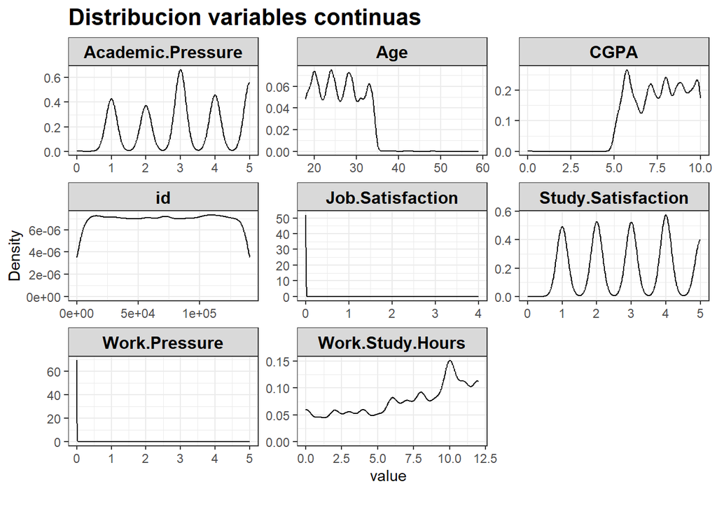

```r
plot_density(
  data    = depre %>% select(where(is.numeric)),
  ncol    = 3,
  title   = "Distribucion variables continuas",
  ggtheme = theme_bw(),
  theme_config = list(
    plot.title = element_text(size = 16, face = "bold"),
    strip.text = element_text(colour = "black", size = 12, face = 2)
  )
)
```

## Correlación variables continuas

Se analiza la matriz de correlación para identificar variables altamente correlacionadas (multicolinealidad).

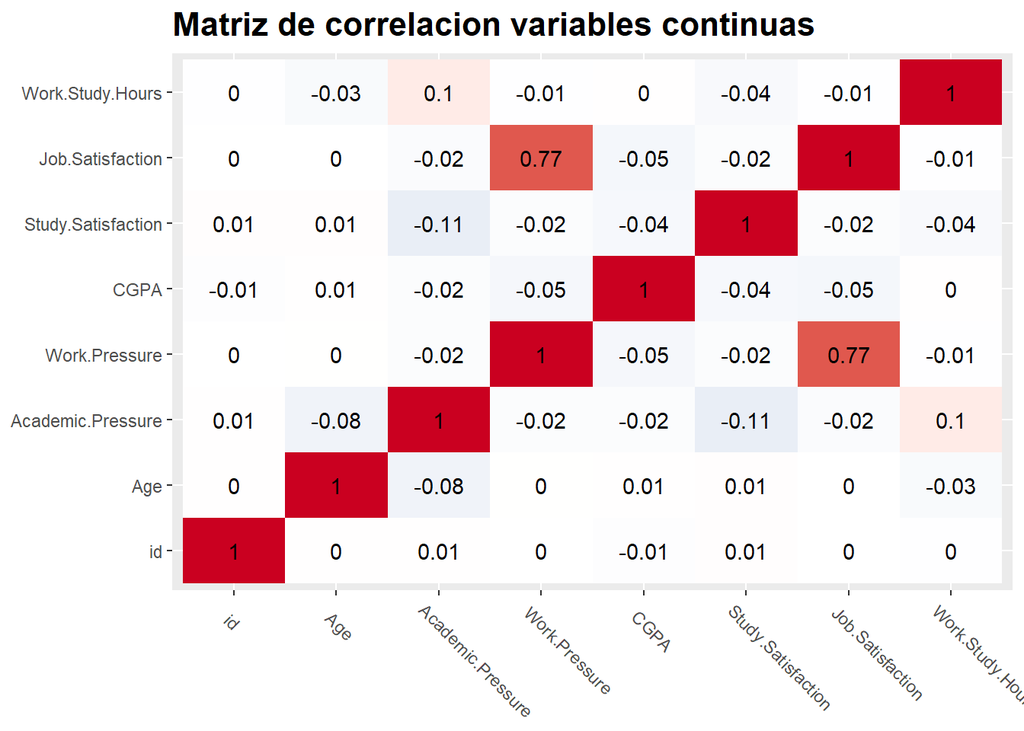

```r
plot_correlation(
  data = depre,
  type = "continuous",
  title = "Matriz de correlacion variables continuas",
  theme_config = list(legend.position = "none",
                      plot.title = element_text(size = 16, face = "bold"),
                      axis.title = element_blank(),
                      axis.text.x = element_text(angle = -45, hjust = +0.1)
                     )
)
```

La matriz de correlación muestra una asociación lineal fuerte entre Job Satisfaction y Work Pressure (r = 0.77). Para evaluar si esta correlación induce multicolinealidad problemática en el modelo de regresión logística, procedo a calcular los Factores de Inflación de Varianza (VIF).

```r
modelo_completo <- glm(Depression ~ ., data = depre, family = binomial)
vif(modelo_completo)
```

```
##                                           GVIF Df GVIF^(1/(2*Df))
## id                                    1.002512  1        1.001255
## Gender                                1.021843  1        1.010862
## Age                                   1.718130  1        1.310774
## Profession                            1.008908  7        1.000634
## Academic.Pressure                     1.097024  1        1.047389
## Work.Pressure                         1.582772  1        1.258083
## CGPA                                  1.016697  1        1.008314
## Study.Satisfaction                    1.023080  1        1.011474
## Job.Satisfaction                      1.583669  1        1.258439
## Sleep.Duration                        1.023256  4        1.002878
## Dietary.Habits                        1.037485  3        1.006152
## Degree                                1.810369 27        1.011052
## Have.you.ever.had.suicidal.thoughts.. 1.090012  1        1.044036
## Work.Study.Hours                      1.020319  1        1.010109
## Financial.Stress                      1.061728  5        1.006008
## Family.History.of.Mental.Illness      1.005218  1        1.002606
```

### Variables cualitativas

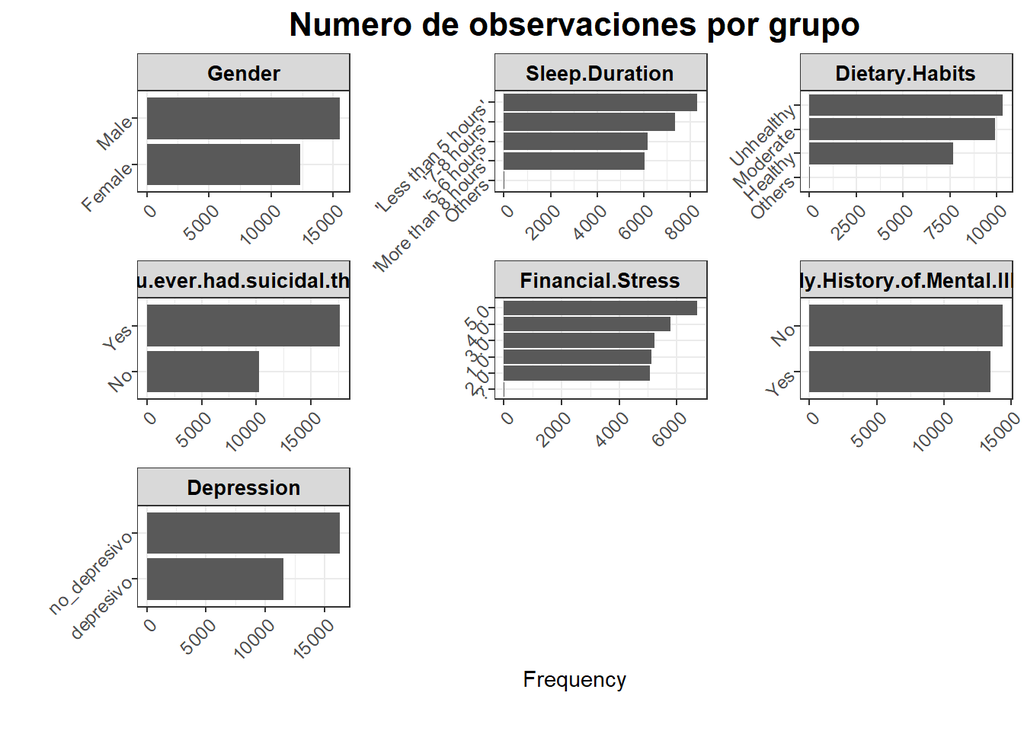

```r
plot_bar(
  data = depre %>% select(-Degree, - Profession),
  ncol = 3,
  title = "Numero de observaciones por grupo",
  ggtheme = theme_bw(),
  theme_config = list(
    plot.title = element_text(size = 16, face = "bold", hjust = 0.5),
    strip.text = element_text(colour = "black", size = 10, face = "bold"),
    axis.text.x = element_text(angle = 45, hjust = 1, size = 9),  # Rotar etiquetas
    axis.text.y = element_text(angle = 45, size = 9),
    legend.position = "none"
  )
)
```

También observamos variables con muchas categorías, como es el caso de Profession y Degree.

```r
table(depre$Profession)
```

```
##
##         'Civil Engineer'         'Content Writer'       'Digital Marketer'
##                        1                        2                        3
## 'Educational Consultant'         'UX/UI Designer'                    Other
##                        1                        1                       17
##                  Student                  Teacher
##                    27870                        6
```

```r
table(depre$Degree)
```

```
##
## 'Class 12'     B.Arch      B.Com       B.Ed    B.Pharm     B.Tech         BA
##       6080       1478       1506       1867        810       1152        600
##        BBA        BCA         BE        BHM        BSc        LLB        LLM
##        696       1433        613        925        888        671        482
##      M.Com       M.Ed    M.Pharm     M.Tech         MA        MBA       MBBS
##        734        821        582       1022        544        562        696
##        MCA         MD         ME        MHM        MSc     Others        PhD
##       1044        572        185        191       1190         35        522
```

## Modelado

### Divido los datos

```r
#seteo la semilla
set.seed(123)

#divido los datos
depre_split <- initial_split(depre, strata = Depression)
depre_train <- training(depre_split)
depre_test <- testing(depre_split)
```

```r
#folds de validación cruzada
set.seed(123)
depre_folds <- vfold_cv(depre_train, strata = Depression)
depre_folds
```

```
## #  10-fold cross-validation using stratification
## # A tibble: 10 × 2
##    splits               id
##    <list>               <chr>
##  1 <split [18831/2094]> Fold01
##  2 <split [18831/2094]> Fold02
##  3 <split [18832/2093]> Fold03
##  4 <split [18833/2092]> Fold04
##  5 <split [18833/2092]> Fold05
##  6 <split [18833/2092]> Fold06
##  7 <split [18833/2092]> Fold07
##  8 <split [18833/2092]> Fold08
##  9 <split [18833/2092]> Fold09
## 10 <split [18833/2092]> Fold10
```

```r
depre_train %>%
  count(Depression)
```

```
##     Depression     n
## 1 no_depresivo 12252
## 2    depresivo  8673
```

```r
depre_test %>%
  count(Depression)
```

```
##     Depression    n
## 1 no_depresivo 4084
## 2    depresivo 2892
```

## Receta

Preprocesamos los datos para el modelo de Machine Learning.

```r
logistic_recipe <-
  recipe(formula = Depression ~ ., data = depre_train) %>%
  update_role(id, new_role = "id") %>%
  step_unknown(all_nominal_predictors()) %>%
  step_downsample(Depression)%>%
  step_other(Profession, threshold = 0.01, other = "Other")
```

## Modelo

El algoritmo a utilizar es el de regresión logística binomial, que clasifica la variable dependiente en dos categorías: Depresivo y No depresivo.

```r
logistic_spec <- logistic_reg() %>%
  set_mode("classification")
```

## Workflow

```r
log_workflow <- workflow() %>%
  add_recipe(logistic_recipe) %>%
  add_model(logistic_spec)
```

## Entrenamiento del algoritmo

```r
doParallel::registerDoParallel()
set.seed(123)
logistic_rs <-
  fit_resamples(log_workflow,
    resamples = depre_folds,
    control = control_resamples(save_pred = TRUE)
  )
```

## Perfomance

Vemos la perfomance del modelo en Train.

```r
logistic_rs %>%
  collect_metrics()
```

```
## # A tibble: 3 × 6
##   .metric     .estimator  mean     n std_err .config
##   <chr>       <chr>      <dbl> <int>   <dbl> <chr>
## 1 accuracy    binary     0.843    10 0.00286 pre0_mod0_post0
## 2 brier_class binary     0.112    10 0.00182 pre0_mod0_post0
## 3 roc_auc     binary     0.920    10 0.00270 pre0_mod0_post0
```

```r
predicciones <- collect_predictions(logistic_rs)
```

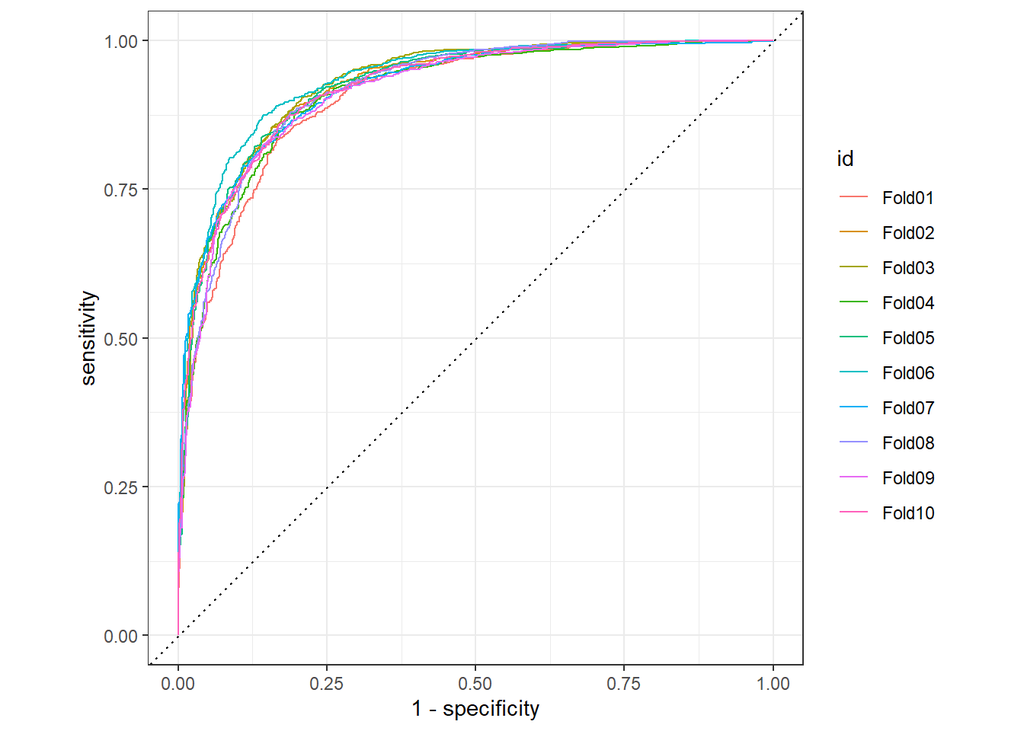

```r
collect_predictions(logistic_rs) %>%
  group_by(id) %>%
  roc_curve(Depression, .pred_no_depresivo) %>%
  autoplot()
```

## Predicción

```r
final_fitted <- last_fit(log_workflow, depre_split)
final_fitted
```

```
## # Resampling results
## # Manual resampling
## # A tibble: 1 × 6
##   splits               id              .metrics .notes   .predictions .workflow
##   <list>               <chr>           <list>   <list>   <list>       <list>
## 1 <split [20925/6976]> train/test spl… <tibble> <tibble> <tibble>     <workflow>
```

## Métricas

```r
final_fitted %>%
  collect_metrics()
```

```
## # A tibble: 3 × 4
##   .metric     .estimator .estimate .config
##   <chr>       <chr>          <dbl> <chr>
## 1 accuracy    binary         0.846 pre0_mod0_post0
## 2 roc_auc     binary         0.922 pre0_mod0_post0
## 3 brier_class binary         0.110 pre0_mod0_post0
```

## Predicciones del modelo

```r
final_fitted %>%
  collect_predictions()
```

```
## # A tibble: 6,976 × 7
##    .pred_class .pred_no_depresivo .pred_depresivo id    Depression  .row .config
##    <fct>                    <dbl>           <dbl> <chr> <fct>      <int> <chr>
##  1 depresivo               0.0110          0.989  trai… depresivo      6 pre0_m…
##  2 depresivo               0.469           0.531  trai… no_depres…    13 pre0_m…
##  3 depresivo               0.162           0.838  trai… depresivo     14 pre0_m…
##  4 no_depresi…             0.502           0.498  trai… no_depres…    16 pre0_m…
##  5 depresivo               0.183           0.817  trai… depresivo     21 pre0_m…
##  6 no_depresi…             0.914           0.0859 trai… no_depres…    23 pre0_m…
##  7 depresivo               0.202           0.798  trai… no_depres…    27 pre0_m…
##  8 depresivo               0.0515          0.949  trai… depresivo     39 pre0_m…
##  9 depresivo               0.202           0.798  trai… depresivo     45 pre0_m…
## 10 depresivo               0.0805          0.919  trai… depresivo     46 pre0_m…
## # ℹ 6,966 more rows
```

## Matriz de confusión

```r
final_fitted %>%
  collect_predictions() %>%
  conf_mat(Depression, .pred_class)
```

```
##               Truth
## Prediction     no_depresivo depresivo
##   no_depresivo         3487       478
##   depresivo             597      2414
```

En la matriz de confusión, la diagonal principal contiene las clasificaciones correctas: verdaderos positivos (VP) y verdaderos negativos (VN), mientras que la diagonal secundaria muestra los errores: falsos positivos (FP) y falsos negativos (FN).